# Assignment 1: Data Mini-project

Vince Currie

18-NOV-2024

```r
#
# Set the default behaviour for displaying code in all chunks to ensure that all chunks will display their code,
# unless turned off within a specific chunk.
#
knitr::opts_chunk$set(echo = TRUE, warning = FALSE)
```

# 1 **Part A**: Data Mini-project

## 1.1 Acronyms

| Acronym | Definition |
| --- | --- |
| ISCED | International Standard Classification of education |
| ISCED 1 | Primary school |

## 1.2 Loading libraries

### 1.2.1 In this section, you need to load the libraries you will use. This section should be located at the top of the Rmd file.

The libraries are loaded silently in this step.

## 1.3 Research Question

### 1.3.1 Describe in 2 sentences maximum a question you would like to investigate/answer in this report using your selected data.

The research focuses on asking the following questions:

1. Are both genders now on a course towards achieving comparable educational attainment worldwide? And,
2. How do the average school years vary across different countries, and what might contribute to differences in education levels between countries?

## 1.4 Data Introduction

```r
#
# Global variables.
#
project_dir <- here::here()

#
# The data read from the files that were downloaded from the
# "Our world in data web site": https://ourworldindata.org/).
# The two CSV files contain the average years of schooling for female and male subjects.
#
data1 <- read.csv(here::here("Data", "mean-years-of-schooling-female.csv"))
data2 <- read.csv(here::here("Data", "mean-years-of-schooling-male.csv"))

#
# Add a gender factor column with "Female" as the only level for the female data and
# "male" for the male data.
#
data1$gender <- factor(rep("Female", nrow(data1)), levels = "Female")
data2$gender <- factor(rep("Male", nrow(data2)), levels = "Male")

#
# Rename the 4th column of both data frames to ensure they are named the same because
# data1 included "female" and data2 used "male" in their names, respectively.
#
names(data1)[4] <- "SchoolYears"
names(data2)[4] <- "SchoolYears"

#
# In addiction, rename "Entity" to "Country" and
# "Code" to "Ccode" for country code.
#
names(data1)[1] <- "Country"
names(data2)[1] <- "Country"
names(data1)[2] <- "Ccode"
names(data2)[2] <- "Ccode"


#
# Combine the two datasets row-wise.
#
all_data <- rbind(data1, data2)
```

```r
#
# Extract column names and data types.
#    Notes: "sapply()" applies the class function to each column.
#    in "all_data" to determine its type.
#
str_table <- data.frame(
  Column = names(all_data),
  Type = sapply(all_data, class),
  row.names = NULL
)

#
# Display column names and data types as a formatted table.
# Requires the format parameter due to a known issue of double printing the "Table":
#    https://github.com/haozhu233/kableExtra/issues/831
#
knitr::kable(
  str_table,
  col.names = c("Column Name", "Data Type"),
  booktabs = TRUE,
  format = "html"
) %>%
  kableExtra::kable_styling(
    bootstrap_options = c("striped", "hover"),
    position = "center",
    full_width = FALSE
  )
```

Table 1.1: Column Names and Data Types.

| Column Name | Data Type |
| --- | --- |
| Country | character |
| Ccode | character |
| Year | integer |
| SchoolYears | numeric |
| gender | factor |

### 1.4.2 Briefly describe your variables (in no more than 3 sentences for all the variables).

The data concerns the mean number of times in years of education for individuals sampled across countries over several years. The two datasets are combined to perform the analysis and answer the research question.

### 1.4.3 Create a table using the kable() function from the knitr package to report the variable names.

Shown in Table 1.1 are the variables and their data types of the combined table containing male and female data. The *Country* column indicates the country from which the data comes and is a character string. Similarly, the *Ccode* column is a string and a three-letter acronym for the country. The *year* indicates when it was collected and is an integer. The *SchoolYears* column metric reflects the average duration of education in years that people in that country undertook, stored as a float. And finally, the *Gender* variable is a factor value indicating Male or Female.

## 1.5 Data Set Description

### 1.5.1 Using inline R code, write a sentence describing the number of variables and observations in your data set.

The combined data frame contains **three thousand and four** records. Table 1.1 shows the **five** variables and their data types.

### 1.5.2 In addition, create a screenshot image of your code and save it as a png file. Upload this png file inside the ‘Image’ folder in your Rstudio Cloud project.

Figure 1.1 shows an example of loading a picture of code into the R markdown document.

### 1.5.3 Using the function str() display the first 2 rows of the data so you can show the type of variables in the data set (numeric, character/factor etc.).

Figure 1.1:

Picture of Code

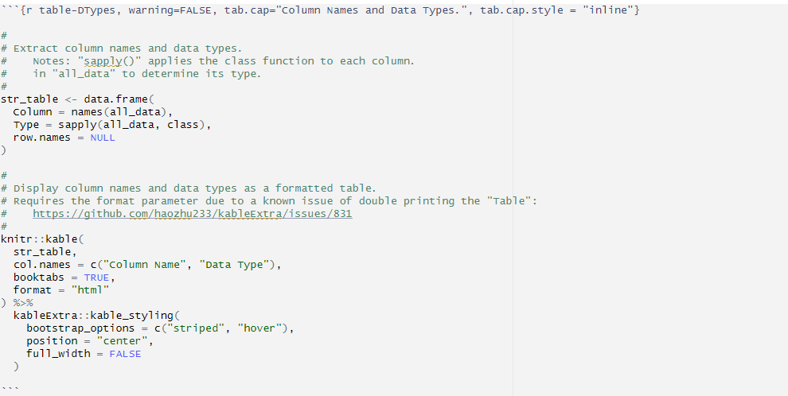

```r
  knitr::include_graphics(here::here("Images", "code_screenshot.png"),rel_path=FALSE)
```

```r
#
# The "capture.output()" captures the console output of str().
# Capture the output of str() for the first two rows.
str_output <- capture.output(str(all_data[1:2, ]))

#
# Convert the captured output to a data frame.
#
str_output_df <- data.frame(StructureInfo = str_output)

#
# Remove the first row (after the column name) which is the str output about
# the observations and variable number which has already been discussed.
# The str_output_df[-1, , drop = FALSE] removes the first row of data while keeping
# the column name intact.
#
str_output_df <- str_output_df[-1, ,drop = FALSE]

#
# Display the output from str() for the first two rows.
#
knitr::kable(str_output_df, longtable = TRUE, align = "c", format = "html") %>%
  kableExtra::kable_styling(
    bootstrap_options = c("striped", "hover"),
    position = "center",
    full_width = FALSE)
```

Table 1.2: A Sample of the First Two Rows.

|  | StructureInfo |
| --- | --- |
| 2 | $ Country : chr “Afghanistan” “Afghanistan” |
| 3 | $ Ccode : chr “AFG” “AFG” |
| 4 | $ Year : int 1975 1979 |
| 5 | $ SchoolYears: num 0.212 0.157 |
| 6 | $ gender : Factor w/ 2 levels “Female”,“Male”: 1 1 |

```r
#
# Visualize missingness pattern.
# A 1 indicates no missing values and 0 indicates missing values.
#
md.pattern(all_data)
```

```
##  /\     /\
## {  `---'  }
## {  O   O  }
## ==>  V <==  No need for mice. This data set is completely observed.
##  \  \|/  /
##   `-----'
```

Figure 1.2: Check for  
Missing Values

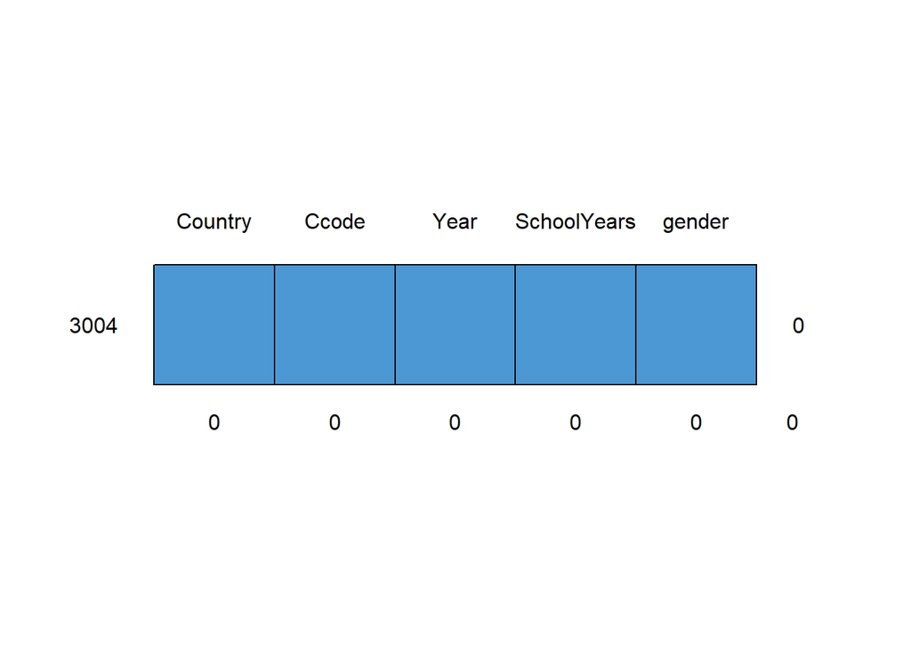

```
##      Country Ccode Year SchoolYears gender
## 3004       1     1    1           1      1 0
##            0     0    0           0      0 0
```

## 1.6 Data Summary

### 1.6.1 Using functions from the dplyr package, select 2 numerical variables and one character/factor variable.

```r
#
# Calculate the mean years in education per country and Gender.
# The group_by(Country, Gender) groups the data country and Gender.
#
mean_education <- all_data %>%
#  filter(Country == "Afghanistan") %>%
  group_by(Country, gender) %>%
  summarise(
  # Education statistics
            meanEd = round(mean(SchoolYears, na.rm = TRUE),2),
            medEd = round(median(SchoolYears, na.rm = TRUE),2),
            minEd = round(min(SchoolYears, na.rm = TRUE),2),
            maxEd = round(max(SchoolYears, na.rm = TRUE),2),
            StdDevEd = round(ifelse(is.na(sd(SchoolYears, na.rm = TRUE)),0,
                                  sd(SchoolYears, na.rm = TRUE)),2),
   # Year statistics
           meanYear = round(mean(Year, na.rm = TRUE), 0),
           medYear = round(median(Year, na.rm = TRUE), 0),
           minYear = round(min(Year, na.rm = TRUE), 0),
           maxYear = round(max(Year, na.rm = TRUE), 0),
           StdDevYear = round(sd(Year, na.rm = TRUE), 0),  # Standard deviation for Year

            .groups = "drop")
#
# Display top and bottom 6 rows of the 'mean_education' table.
#
mean_education_12 <- rbind(head(mean_education,6),tail(mean_education,6))

#
# Display the summary as a formatted table.
#
kable(mean_education_12, format = "html",
      caption = "Top Six and Bottom Rows <br> Showing Statistics <br> for Years of Schooling (Ed) and Years of Data Collection (Year) <br> \
      by Country and Gender.") %>%
 kable_styling(bootstrap_options = c("striped", "hover"),
               full_width = FALSE)
```

Table 1.3: Top Six and Bottom Rows Showing Statistics for Years of Schooling (Ed) and Years of Data Collection (Year) by Country and Gender.

| Country | gender | meanEd | medEd | minEd | maxEd | StdDevEd | meanYear | medYear | minYear | maxYear | StdDevYear |
| --- | --- | --- | --- | --- | --- | --- | --- | --- | --- | --- | --- |
| Afghanistan | Female | 0.92 | 0.75 | 0.16 | 2.31 | 0.88 | 2002 | 2015 | 1975 | 2022 | 23 |
| Afghanistan | Male | 2.68 | 3.40 | 1.18 | 3.91 | 1.26 | 2002 | 2015 | 1975 | 2022 | 23 |
| Albania | Female | 9.18 | 9.40 | 8.24 | 9.83 | 0.67 | 2010 | 2011 | 2001 | 2017 | 6 |
| Albania | Male | 10.01 | 10.22 | 9.42 | 10.30 | 0.37 | 2010 | 2011 | 2001 | 2017 | 6 |
| Algeria | Female | 4.46 | 5.16 | 0.24 | 6.50 | 2.43 | 2003 | 2008 | 1971 | 2019 | 19 |
| Algeria | Male | 5.97 | 7.17 | 1.66 | 7.54 | 2.45 | 2003 | 2008 | 1971 | 2019 | 19 |
| Vietnam | Female | 6.55 | 7.03 | 3.56 | 8.52 | 2.03 | 2004 | 2009 | 1979 | 2022 | 19 |
| Vietnam | Male | 7.71 | 8.12 | 4.64 | 9.47 | 1.87 | 2004 | 2009 | 1979 | 2022 | 19 |
| Zambia | Female | 3.88 | 3.23 | 2.26 | 6.15 | 2.03 | 1996 | 1990 | 1980 | 2018 | 20 |
| Zambia | Male | 6.21 | 5.78 | 4.75 | 8.10 | 1.71 | 1996 | 1990 | 1980 | 2018 | 20 |
| Zimbabwe | Female | 7.05 | 7.51 | 4.49 | 8.07 | 1.33 | 2010 | 2014 | 1992 | 2019 | 10 |
| Zimbabwe | Male | 8.40 | 8.86 | 6.24 | 9.46 | 1.11 | 2010 | 2014 | 1992 | 2019 | 10 |

### 1.6.2 Using some of the available options inside the kable() function add a caption for the table.

```r
#
# Create an education_gap column by calculating the difference between
# male and female min/max years of education.
#
mean_education_with_gap <- mean_education %>%
#  filter(Country == "Afghanistan") %>%
  select(Country, gender, minEd, maxEd) %>%
  pivot_wider(names_from = gender, values_from = c(minEd,maxEd)) %>%
 rename( # Rename columns for clarity
    min_male = minEd_Male,
    min_female = minEd_Female,
    max_male = maxEd_Male,
    max_female = maxEd_Female
  ) %>%
 mutate(
   min_education_gap = min_male - min_female,
   max_education_gap = max_male - max_female
 )


#
# Display top and bottom 6 rows of the 'mean_education' table.
#
mean_education_with_gap_12 <- rbind(head(mean_education_with_gap,6),tail(mean_education_with_gap,6))

#
# Display the summary as a formatted table.
#
kable(mean_education_with_gap_12, format = "html",
      caption = "Top Six and Bottom Rows <br> Showing Years of Schooling Gender Gap <br> by Country.") %>%
 kable_styling(bootstrap_options = c("striped", "hover"),
               full_width = FALSE)
```

Table 1.4: Top Six and Bottom Rows Showing Years of Schooling Gender Gap by Country.

| Country | min_female | min_male | max_female | max_male | min_education_gap | max_education_gap |
| --- | --- | --- | --- | --- | --- | --- |
| Afghanistan | 0.16 | 1.18 | 2.31 | 3.91 | 1.02 | 1.60 |
| Albania | 8.24 | 9.42 | 9.83 | 10.30 | 1.18 | 0.47 |
| Algeria | 0.24 | 1.66 | 6.50 | 7.54 | 1.42 | 1.04 |
| American Samoa | 8.53 | 9.53 | 10.32 | 10.82 | 1.00 | 0.50 |
| Andorra | 9.96 | 10.09 | 11.52 | 11.70 | 0.13 | 0.18 |
| Angola | 3.13 | 4.95 | 4.12 | 6.82 | 1.82 | 2.70 |
| Uruguay | 5.77 | 5.71 | 9.25 | 8.74 | -0.06 | -0.51 |
| Uzbekistan | 11.07 | 11.48 | 11.75 | 12.09 | 0.41 | 0.34 |
| Venezuela | 2.86 | 3.53 | 10.60 | 10.02 | 0.67 | -0.58 |
| Vietnam | 3.56 | 4.64 | 8.52 | 9.47 | 1.08 | 0.95 |
| Zambia | 2.26 | 4.75 | 6.15 | 8.10 | 2.49 | 1.95 |
| Zimbabwe | 4.49 | 6.24 | 8.07 | 9.46 | 1.75 | 1.39 |

### 1.6.3 Describe in two sentences what you observe from the data summary, and write one of the words in the sentence using bold font.

Table 1.3 summarises education data, but this discussion considers only the rows displayed, highlighting critical statistics for years of schooling and record collection. For example, In Afghanistan, there is a significant gap between males and females, with females averaging 0.92 years and males 2.68 years. The median years of education are also lower for females, at 0.75 years compared to 3.40 years for males. In Albania, the educational gap is minimal, with males averaging 10.01 years of schooling and females 9.18 years. Afghanistan has a notably low mean of 0.92 years for females. Consequently, educational opportunities are more equally distributed between genders in Albania, though males still generally have a slight advantage in terms of years of schooling.

The table highlights **gender disparities in education**, particularly in Afghanistan, where girls receive significantly less schooling than boys. Overall, the data collected spans from 1971 to 2022. Afghanistan’s records cover a long period from 1975 to 2022, with a standard deviation of 23 years. In contrast, Albania has a standard deviation of 6 years, with data collection from 2001 to 2017. The difference emphasises that the disparity in Afghanistan has occurred over a long period without much improvement.

Table 1.4 shows the education gap for the rows displayed at the lower and higher ends of education. In Afghanistan, girls average only 0.92 years of schooling, peaking at 2.31 years, while boys average 2.68 years, with a maximum of 3.91 years. The significant education gap, ranging from 1.02 to 1.60 years, highlights the disparity in access to education based on gender. However, educational options for both genders are approximately < four years, indicating multifaceted economic, political and cultural issues.

## 1.7 Visualisations

### 1.7.1 Create one figure (connected with your research question) of your data and add a caption using the relevant options inside the R code chunk

Figure 1.3: Education Disparity by Country & Gender  
for Twelve Rows

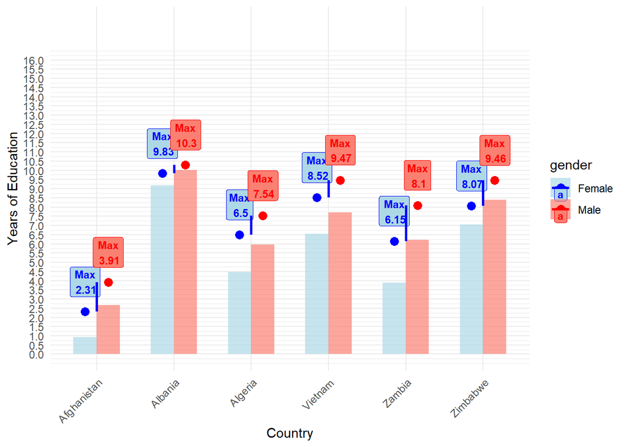

```r
#
# Exclude Vietnam and Algeria, and create the plot.
# Vietnam and Algeria are missing the required two records
# within the ten rows being examined so they are excluded.
#
ggplot(mean_education_12,
        aes(x = Country, fill = gender)) +
  # Bar plot for mean education.
  geom_bar(aes(y = meanEd), stat = "identity", position = "dodge", width = 0.6, alpha = 0.7) +

  # Point plot for maximum education (overlayed on the bar plot).
  geom_point(aes(y = maxEd, color = gender), size = 3, position = position_dodge(width = 0.6)) +

  # Add text labels for the maximum education points.
  geom_label(aes(y = maxEd, label = paste("Max\n", round(maxEd, 2)), color = gender),
           position = position_dodge(width = 0.6), vjust = -0.5, size = 3, fontface = "bold") +

   # Set the y-axis with more ticks
  scale_y_continuous(breaks = seq(0, 16, by = 0.5), limits = c(0, 18)) +  # Increase the ticks

  # Line to join the points for maximum education.
  geom_line(aes(y = maxEd, group = Country, color = gender), size = 1, position = position_dodge(width = 0.6)) +

  # Customize the plot.
  labs(x = "Country", y = "Years of Education") +
  theme_minimal() +
  scale_fill_manual(values = c("lightblue", "salmon")) +
  scale_color_manual(values = c("blue", "red")) +
  theme(axis.text.x = element_text(angle = 45, hjust = 1))
```

### 1.7.2 Using markdown language, add a list with two bullet points describing what you see in the figure using italic font.

- *Afghanistan has a notable gender gap in education, with females averaging only 0.92 years (refer to Table 1.3) of schooling (max 2.31 years) compared to males at 2.68 years (refer to Table 1.3) (max 3.91 years). The disparity is likely due to cultural, social, and political factors, highlighting significant inequalities in access to education for women.*
- *Albania demonstrates better gender equality in education, with girls averaging 9.18 years and boys 10.01 years. The minor differences in the educational gap (refer to Table 1.4) from the least educated (1.18 years) to the highest educated (0.47 years) indicate approximately equal educational opportunities for both genders.*

## 1.8 Conclusions

# 2 **Part B**: Mini-Project Repository

## 2.1 Create your GitHub repository and link your mini-project.

The steps below were used to set-up a repository and create a new branch for part 2.

1. Create a new repository in github (https://github.com/Vincemonash/Assignment1.git).
2. git init
3. git add .
4. git commit -m “Initial commit for Assignment1 R project”
5. git remote add origin https://github.com/Vincemonash/Assignment1.git
6. git remote -v
7. git push -u origin master
8. git checkout -b asspart2
9. git add .
10. git commit -m “Changes to accomodate part 2 of assignment 1”
11. git push -u origin asspart2

### 2.1.1 The data files need to be inside a folder called Data. If you need to process the data to reduce the size do it before you include the data in your repository.

The ‘data’ directory add for the data files.

### 2.1.2 Ensure you commit changes with clear messages so we can understand what you did in each commit.

Use the following example command: git commit -m “Changes to accomodate part 2 of assignment 1”.

### 2.1.3 Create two branches and work in them for a few commits at different times.

One branch created: “git checkout -b asspart2”. Second branch created: “git checkout -b asspart2B”.

echo “# ETO5513 Assignment 1” > README.md git add README.md git commit -m “Add README.md for Assignment 1”

git checkout master git pull origin master git merge asspart2B

git switch asspart2 vi README.md

git switch asspart2B vi README.md

### 2.1.4 Merge them with the master branch.

git switch master git checkout master git pull origin master git merge asspart2B

git merge asspart2

### 2.1.5 Make sure that at least one branch creates a conflict with your master branch.

#### 2.1.5.1 Create commits that show clearly that you merged the branches. In addition, make sure that you have a commit showing that you fixed at least one merging conflict.

$ git merge asspart2 Auto-merging README.md CONFLICT (content): Merge conflict in README.md Automatic merge failed; fix conflicts and then commit the result.

git commit -m “Resolved merge conflict in README.md”

$ vi README.md

USER@DESKTOP-KGR3EOI MINGW64 /d/Monash/ETO5513/Assignment1 (master|MERGING) $

USER@DESKTOP-KGR3EOI MINGW64 /d/Monash/ETO5513/Assignment1 (master|MERGING) $

USER@DESKTOP-KGR3EOI MINGW64 /d/Monash/ETO5513/Assignment1 (master|MERGING) $ git add README.md

USER@DESKTOP-KGR3EOI MINGW64 /d/Monash/ETO5513/Assignment1 (master|MERGING) $ git commit -m “Resolved merge conflict in README.md” [master cde8057] Resolved merge conflict in README.md

USER@DESKTOP-KGR3EOI MINGW64 /d/Monash/ETO5513/Assignment1 (master) $ git push Enumerating objects: 15, done. Counting objects: 100% (14/14), done. Delta compression using up to 12 threads Compressing objects: 100% (11/11), done. Writing objects: 100% (11/11), 1.20 KiB | 1.20 MiB/s, done. Total 11 (delta 5), reused 0 (delta 0), pack-reused 0 (from 0) remote: Resolving deltas: 100% (5/5), completed with 1 local object. To https://github.com/Vincemonash/Assignment1.git 94f65d2..cde8057 master -> master

## 2.2 Expand on Your Simple report

### 2.2.1 include one additional figure and table describing the data

Figure 2.1: Gender Education Gap by Country  
for Twelve Rows

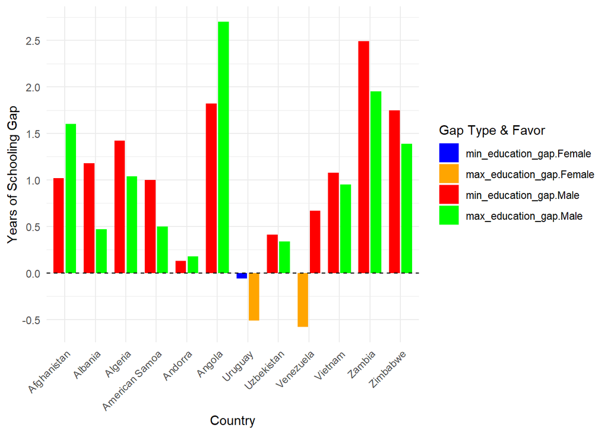

```r
#
# Transform the data into long format for ggplot.
#
data_long <- reshape2::melt(mean_education_with_gap_12,
                            id.vars = "Country",
                            measure.vars = c("min_education_gap","max_education_gap"),
                            variable.name = "Gap_Type",
                            value.name = "Gap_Value")

#
# Add a column to distinguish male vs female gap visually.
#
data_long$Gap_Favor <- ifelse(data_long$Gap_Value > 0, "Male", "Female")

#
# Produce the graph that shows which way education gap points:
# Negative is female and positive is male.
#
ggplot(data_long, aes(x = Country, y = Gap_Value, fill = interaction(Gap_Type, Gap_Favor))) +
  geom_bar(stat = "identity", position = position_dodge(width = 0.8), width = 0.7) +
  scale_fill_manual(values = c(
    "min_education_gap.Female" = "blue",
    "min_education_gap.Male" = "red",
    "max_education_gap.Male" = "green",
    "max_education_gap.Female" = "orange"
  )) +
  geom_hline(yintercept = 0, color = "black", linetype = "dashed") +
  scale_y_continuous(breaks = seq(-1, 10, 0.5)) + # Adds more y-axis ticks from -1 to 10 in steps of 0.5
  labs(
    x = "Country",
    y = "Years of Schooling Gap",
    fill = "Gap Type & Favor"
  ) +
  theme_minimal() +
  theme(axis.text.x = element_text(angle = 45, hjust = 1))
```

# References

*Mean years of schooling (ISCED 1 or higher), female*. (2021). [Dataset]. Global Change Data Lab. https://ourworldindata.org/grapher/mean-years-of-schooling-female

*Mean years of schooling (ISCED 1 or higher), male*. (2021). [Dataset]. Global Change Data Lab. https://ourworldindata.org/grapher/mean-years-of-schooling-male